# Risk Factor Analysis

## Outcome Variable

**Outcome Variable:** sstunted

## Predictor Variables

**Intervention Variable:** hdlvry

**Adjustment Set:**

- arm
- sex
- W_mage
- meducyrs
- feducyrs
- hhwealth_quart
- hfoodsec
- W_nrooms
- brthmon
- impfloor
- impsan
- safeh20
- delta_W_mage
- delta_meducyrs
- delta_feducyrs
- delta_hhwealth_quart
- delta_hfoodsec
- delta_W_nrooms
- delta_brthmon
- delta_impfloor
- delta_impsan
- delta_safeh20

## Stratifying Variables

The analysis was stratified on these variable(s):

- agecat
- studyid
- country

## Data Summary

| agecat | studyid | country | hdlvry | sstunted | n_cell | n |
| --- | --- | --- | --- | --- | --- | --- |
| Birth | ki1000108-CMC-V-BCS-2002 | INDIA | 0 | 0 | 87 | 90 |
| Birth | ki1000108-CMC-V-BCS-2002 | INDIA | 0 | 1 | 3 | 90 |
| Birth | ki1000108-CMC-V-BCS-2002 | INDIA | 1 | 0 | 0 | 90 |
| Birth | ki1000108-CMC-V-BCS-2002 | INDIA | 1 | 1 | 0 | 90 |
| Birth | ki1000108-IRC | INDIA | 0 | 0 | 365 | 388 |
| Birth | ki1000108-IRC | INDIA | 0 | 1 | 16 | 388 |
| Birth | ki1000108-IRC | INDIA | 1 | 0 | 7 | 388 |
| Birth | ki1000108-IRC | INDIA | 1 | 1 | 0 | 388 |
| Birth | ki1000109-EE | PAKISTAN | 0 | 0 | 4 | 4 |
| Birth | ki1000109-EE | PAKISTAN | 0 | 1 | 0 | 4 |
| Birth | ki1000109-EE | PAKISTAN | 1 | 0 | 0 | 4 |
| Birth | ki1000109-EE | PAKISTAN | 1 | 1 | 0 | 4 |
| Birth | ki1000304b-SAS-CompFeed | INDIA | 0 | 0 | 10 | 180 |
| Birth | ki1000304b-SAS-CompFeed | INDIA | 0 | 1 | 1 | 180 |
| Birth | ki1000304b-SAS-CompFeed | INDIA | 1 | 0 | 160 | 180 |
| Birth | ki1000304b-SAS-CompFeed | INDIA | 1 | 1 | 9 | 180 |
| Birth | ki1017093c-NIH-Crypto | BANGLADESH | 0 | 0 | 21 | 27 |
| Birth | ki1017093c-NIH-Crypto | BANGLADESH | 0 | 1 | 1 | 27 |
| Birth | ki1017093c-NIH-Crypto | BANGLADESH | 1 | 0 | 5 | 27 |
| Birth | ki1017093c-NIH-Crypto | BANGLADESH | 1 | 1 | 0 | 27 |
| Birth | ki1135781-COHORTS | INDIA | 0 | 0 | 2855 | 4694 |
| Birth | ki1135781-COHORTS | INDIA | 0 | 1 | 83 | 4694 |
| Birth | ki1135781-COHORTS | INDIA | 1 | 0 | 1702 | 4694 |
| Birth | ki1135781-COHORTS | INDIA | 1 | 1 | 54 | 4694 |
| Birth | kiGH5241-JiVitA-3 | BANGLADESH | 0 | 0 | 22 | 600 |
| Birth | kiGH5241-JiVitA-3 | BANGLADESH | 0 | 1 | 0 | 600 |
| Birth | kiGH5241-JiVitA-3 | BANGLADESH | 1 | 0 | 548 | 600 |
| Birth | kiGH5241-JiVitA-3 | BANGLADESH | 1 | 1 | 30 | 600 |
| Birth | kiGH5241-JiVitA-4 | BANGLADESH | 0 | 0 | 90 | 1640 |
| Birth | kiGH5241-JiVitA-4 | BANGLADESH | 0 | 1 | 4 | 1640 |

[output cut: 86 more lines]

The following strata were considered:

- agecat: 24 months, studyid: ki1000108-CMC-V-BCS-2002, country: INDIA
- agecat: 24 months, studyid: ki1000108-IRC, country: INDIA
- agecat: 24 months, studyid: ki1017093b-PROVIDE, country: BANGLADESH
- agecat: 24 months, studyid: ki1017093c-NIH-Crypto, country: BANGLADESH
- agecat: 24 months, studyid: ki1066203-TanzaniaChild2, country: TANZANIA, UNITED REPUBLIC OF
- agecat: 24 months, studyid: ki1113344-GMS-Nepal, country: NEPAL
- agecat: 24 months, studyid: ki1135781-COHORTS, country: INDIA
- agecat: 24 months, studyid: kiGH5241-JiVitA-3, country: BANGLADESH
- agecat: 24 months, studyid: kiGH5241-JiVitA-4, country: BANGLADESH
- agecat: 6 months, studyid: ki1000108-CMC-V-BCS-2002, country: INDIA
- agecat: 6 months, studyid: ki1000108-IRC, country: INDIA
- agecat: 6 months, studyid: ki1000109-EE, country: PAKISTAN
- agecat: 6 months, studyid: ki1000304b-SAS-CompFeed, country: INDIA
- agecat: 6 months, studyid: ki1000304b-SAS-FoodSuppl, country: INDIA
- agecat: 6 months, studyid: ki1017093b-PROVIDE, country: BANGLADESH
- agecat: 6 months, studyid: ki1017093c-NIH-Crypto, country: BANGLADESH
- agecat: 6 months, studyid: ki1066203-TanzaniaChild2, country: TANZANIA, UNITED REPUBLIC OF
- agecat: 6 months, studyid: ki1113344-GMS-Nepal, country: NEPAL
- agecat: 6 months, studyid: ki1135781-COHORTS, country: INDIA
- agecat: 6 months, studyid: kiGH5241-JiVitA-3, country: BANGLADESH
- agecat: 6 months, studyid: kiGH5241-JiVitA-4, country: BANGLADESH
- agecat: Birth, studyid: ki1000108-CMC-V-BCS-2002, country: INDIA
- agecat: Birth, studyid: ki1000108-IRC, country: INDIA
- agecat: Birth, studyid: ki1000109-EE, country: PAKISTAN
- agecat: Birth, studyid: ki1000304b-SAS-CompFeed, country: INDIA
- agecat: Birth, studyid: ki1017093c-NIH-Crypto, country: BANGLADESH
- agecat: Birth, studyid: ki1135781-COHORTS, country: INDIA
- agecat: Birth, studyid: kiGH5241-JiVitA-3, country: BANGLADESH
- agecat: Birth, studyid: kiGH5241-JiVitA-4, country: BANGLADESH

### Dropped Strata

Some strata were dropped due to rare outcomes:

- agecat: Birth, studyid: ki1000108-CMC-V-BCS-2002, country: INDIA
- agecat: Birth, studyid: ki1000108-IRC, country: INDIA
- agecat: Birth, studyid: ki1000109-EE, country: PAKISTAN
- agecat: Birth, studyid: ki1000304b-SAS-CompFeed, country: INDIA
- agecat: Birth, studyid: ki1017093c-NIH-Crypto, country: BANGLADESH
- agecat: Birth, studyid: kiGH5241-JiVitA-3, country: BANGLADESH
- agecat: Birth, studyid: kiGH5241-JiVitA-4, country: BANGLADESH
- agecat: 6 months, studyid: ki1000108-CMC-V-BCS-2002, country: INDIA
- agecat: 6 months, studyid: ki1000108-IRC, country: INDIA
- agecat: 6 months, studyid: ki1017093c-NIH-Crypto, country: BANGLADESH
- agecat: 6 months, studyid: ki1066203-TanzaniaChild2, country: TANZANIA, UNITED REPUBLIC OF
- agecat: 6 months, studyid: ki1113344-GMS-Nepal, country: NEPAL
- agecat: 6 months, studyid: kiGH5241-JiVitA-3, country: BANGLADESH
- agecat: 24 months, studyid: ki1000108-CMC-V-BCS-2002, country: INDIA
- agecat: 24 months, studyid: ki1000108-IRC, country: INDIA
- agecat: 24 months, studyid: ki1066203-TanzaniaChild2, country: TANZANIA, UNITED REPUBLIC OF

## Methods Detail

We’re interested in the causal parameters $E[Y_a]$ for all values of $a \in \mathcal{A}$. These parameters represent the mean outcome if, possibly contrary to fact, we intervened to set all units to have $A=a$. Under the randomization and positivity assumptions, these are identified by the statistical parameters $\psi_a=E_W[E_{Y|A,W}(Y|A=a,W)]$. In addition, we’re interested in the mean of $Y$, $E[Y]$ under no intervention (the observed mean). We will estimate these parameters by using SuperLearner to fit the relevant likelihood factors – $E_{Y|A,W}(Y|A=a,W)$ and $p(A=a|W)$, and then updating our likelihood fit using a joint TMLE.

For unadjusted analyses ($W=\{\}$), initial likelihoods were estimated using Lrnr_glm to estimate the simple $E(Y|A)$ and Lrnr_mean to estimate $p(A)$. For adjusted analyses, a small library containing Lrnr_glmnet, Lrnr_xgboost, and Lrnr_mean was used.

Having estimated these parameters, we will then use the delta method to estimate relative risks and attributable risks relative to a prespecified baseline level of $A$.

# Results Detail

## Results Plots

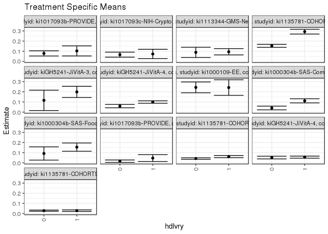

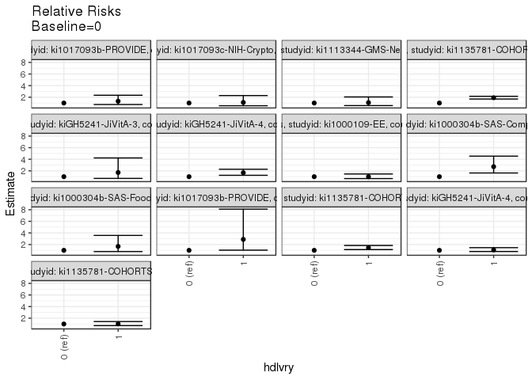

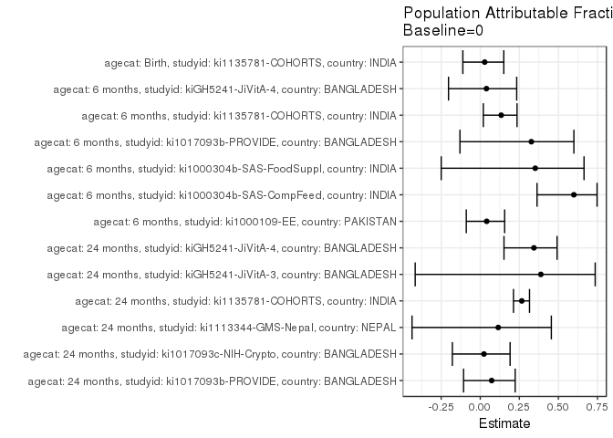

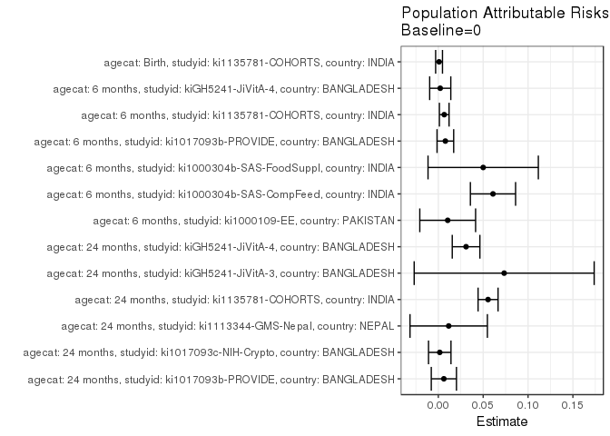

## Results Table

### Parameter: TSM

| agecat | studyid | country | intervention_level | baseline_level | estimate | ci_lower | ci_upper |
| --- | --- | --- | --- | --- | --- | --- | --- |
| Birth | ki1135781-COHORTS | INDIA | 0 | NA | 0.0283581 | 0.0223524 | 0.0343638 |
| Birth | ki1135781-COHORTS | INDIA | 1 | NA | 0.0286100 | 0.0210082 | 0.0362118 |
| 6 months | ki1000109-EE | PAKISTAN | 0 | NA | 0.2436038 | 0.1902006 | 0.2970070 |
| 6 months | ki1000109-EE | PAKISTAN | 1 | NA | 0.2420138 | 0.1653029 | 0.3187246 |
| 6 months | ki1000304b-SAS-CompFeed | INDIA | 0 | NA | 0.0408163 | 0.0221750 | 0.0594577 |
| 6 months | ki1000304b-SAS-CompFeed | INDIA | 1 | NA | 0.1112288 | 0.0906768 | 0.1317809 |
| 6 months | ki1000304b-SAS-FoodSuppl | INDIA | 0 | NA | 0.0921053 | 0.0270064 | 0.1572041 |
| 6 months | ki1000304b-SAS-FoodSuppl | INDIA | 1 | NA | 0.1546053 | 0.1139117 | 0.1952988 |
| 6 months | ki1017093b-PROVIDE | BANGLADESH | 0 | NA | 0.0161663 | 0.0042773 | 0.0280552 |
| 6 months | ki1017093b-PROVIDE | BANGLADESH | 1 | NA | 0.0466667 | 0.0128834 | 0.0804499 |
| 6 months | ki1135781-COHORTS | INDIA | 0 | NA | 0.0425699 | 0.0351716 | 0.0499681 |
| 6 months | ki1135781-COHORTS | INDIA | 1 | NA | 0.0613466 | 0.0507668 | 0.0719265 |
| 6 months | kiGH5241-JiVitA-4 | BANGLADESH | 0 | NA | 0.0520398 | 0.0387809 | 0.0652986 |
| 6 months | kiGH5241-JiVitA-4 | BANGLADESH | 1 | NA | 0.0559665 | 0.0457763 | 0.0661566 |
| 24 months | ki1017093b-PROVIDE | BANGLADESH | 0 | NA | 0.0787413 | 0.0533510 | 0.1041317 |
| 24 months | ki1017093b-PROVIDE | BANGLADESH | 1 | NA | 0.1033628 | 0.0539061 | 0.1528194 |
| 24 months | ki1017093c-NIH-Crypto | BANGLADESH | 0 | NA | 0.0664962 | 0.0417767 | 0.0912156 |
| 24 months | ki1017093c-NIH-Crypto | BANGLADESH | 1 | NA | 0.0731707 | 0.0271040 | 0.1192374 |
| 24 months | ki1113344-GMS-Nepal | NEPAL | 0 | NA | 0.0890749 | 0.0387151 | 0.1394346 |
| 24 months | ki1113344-GMS-Nepal | NEPAL | 1 | NA | 0.0949344 | 0.0641749 | 0.1256938 |
| 24 months | ki1135781-COHORTS | INDIA | 0 | NA | 0.1533275 | 0.1385226 | 0.1681323 |
| 24 months | ki1135781-COHORTS | INDIA | 1 | NA | 0.2928914 | 0.2696642 | 0.3161186 |
| 24 months | kiGH5241-JiVitA-3 | BANGLADESH | 0 | NA | 0.1159420 | 0.0158485 | 0.2160356 |
| 24 months | kiGH5241-JiVitA-3 | BANGLADESH | 1 | NA | 0.1992188 | 0.1442695 | 0.2541680 |
| 24 months | kiGH5241-JiVitA-4 | BANGLADESH | 0 | NA | 0.0591980 | 0.0424057 | 0.0759904 |
| 24 months | kiGH5241-JiVitA-4 | BANGLADESH | 1 | NA | 0.0995814 | 0.0875063 | 0.1116565 |

### Parameter: E(Y)

| agecat | studyid | country | intervention_level | baseline_level | estimate | ci_lower | ci_upper |
| --- | --- | --- | --- | --- | --- | --- | --- |
| Birth | ki1135781-COHORTS | INDIA | NA | NA | 0.0291862 | 0.0243703 | 0.0340021 |
| 6 months | ki1000109-EE | PAKISTAN | NA | NA | 0.2540541 | 0.2096368 | 0.2984713 |
| 6 months | ki1000304b-SAS-CompFeed | INDIA | NA | NA | 0.1017415 | 0.0806841 | 0.1227990 |
| 6 months | ki1000304b-SAS-FoodSuppl | INDIA | NA | NA | 0.1421053 | 0.1069532 | 0.1772573 |
| 6 months | ki1017093b-PROVIDE | BANGLADESH | NA | NA | 0.0240137 | 0.0115761 | 0.0364514 |
| 6 months | ki1135781-COHORTS | INDIA | NA | NA | 0.0491594 | 0.0429771 | 0.0553417 |
| 6 months | kiGH5241-JiVitA-4 | BANGLADESH | NA | NA | 0.0541780 | 0.0458161 | 0.0625400 |
| 24 months | ki1017093b-PROVIDE | BANGLADESH | NA | NA | 0.0849220 | 0.0621566 | 0.1076874 |
| 24 months | ki1017093c-NIH-Crypto | BANGLADESH | NA | NA | 0.0680934 | 0.0462948 | 0.0898920 |
| 24 months | ki1113344-GMS-Nepal | NEPAL | NA | NA | 0.1006424 | 0.0733267 | 0.1279581 |
| 24 months | ki1135781-COHORTS | INDIA | NA | NA | 0.2087665 | 0.1954120 | 0.2221210 |
| 24 months | kiGH5241-JiVitA-3 | BANGLADESH | NA | NA | 0.1893287 | 0.1393793 | 0.2392781 |
| 24 months | kiGH5241-JiVitA-4 | BANGLADESH | NA | NA | 0.0901250 | 0.0799382 | 0.1003118 |

### Parameter: RR

| agecat | studyid | country | intervention_level | baseline_level | estimate | ci_lower | ci_upper |
| --- | --- | --- | --- | --- | --- | --- | --- |
| Birth | ki1135781-COHORTS | INDIA | 0 | 0 | 1.0000000 | 1.0000000 | 1.000000 |
| Birth | ki1135781-COHORTS | INDIA | 1 | 0 | 1.0088822 | 0.7183106 | 1.416996 |
| 6 months | ki1000109-EE | PAKISTAN | 0 | 0 | 1.0000000 | 1.0000000 | 1.000000 |
| 6 months | ki1000109-EE | PAKISTAN | 1 | 0 | 0.9934729 | 0.6752217 | 1.461725 |
| 6 months | ki1000304b-SAS-CompFeed | INDIA | 0 | 0 | 1.0000000 | 1.0000000 | 1.000000 |
| 6 months | ki1000304b-SAS-CompFeed | INDIA | 1 | 0 | 2.7251056 | 1.6370778 | 4.536254 |
| 6 months | ki1000304b-SAS-FoodSuppl | INDIA | 0 | 0 | 1.0000000 | 1.0000000 | 1.000000 |
| 6 months | ki1000304b-SAS-FoodSuppl | INDIA | 1 | 0 | 1.6785713 | 0.7895723 | 3.568516 |
| 6 months | ki1017093b-PROVIDE | BANGLADESH | 0 | 0 | 1.0000000 | 1.0000000 | 1.000000 |
| 6 months | ki1017093b-PROVIDE | BANGLADESH | 1 | 0 | 2.8866667 | 1.0285604 | 8.101463 |
| 6 months | ki1135781-COHORTS | INDIA | 0 | 0 | 1.0000000 | 1.0000000 | 1.000000 |
| 6 months | ki1135781-COHORTS | INDIA | 1 | 0 | 1.4410809 | 1.1295148 | 1.838590 |
| 6 months | kiGH5241-JiVitA-4 | BANGLADESH | 0 | 0 | 1.0000000 | 1.0000000 | 1.000000 |
| 6 months | kiGH5241-JiVitA-4 | BANGLADESH | 1 | 0 | 1.0754556 | 0.7937372 | 1.457163 |
| 24 months | ki1017093b-PROVIDE | BANGLADESH | 0 | 0 | 1.0000000 | 1.0000000 | 1.000000 |
| 24 months | ki1017093b-PROVIDE | BANGLADESH | 1 | 0 | 1.3126875 | 0.7372546 | 2.337251 |
| 24 months | ki1017093c-NIH-Crypto | BANGLADESH | 0 | 0 | 1.0000000 | 1.0000000 | 1.000000 |
| 24 months | ki1017093c-NIH-Crypto | BANGLADESH | 1 | 0 | 1.1003752 | 0.5296782 | 2.285965 |
| 24 months | ki1113344-GMS-Nepal | NEPAL | 0 | 0 | 1.0000000 | 1.0000000 | 1.000000 |
| 24 months | ki1113344-GMS-Nepal | NEPAL | 1 | 0 | 1.0657820 | 0.5554281 | 2.045074 |
| 24 months | ki1135781-COHORTS | INDIA | 0 | 0 | 1.0000000 | 1.0000000 | 1.000000 |
| 24 months | ki1135781-COHORTS | INDIA | 1 | 0 | 1.9102344 | 1.6881909 | 2.161483 |
| 24 months | kiGH5241-JiVitA-3 | BANGLADESH | 0 | 0 | 1.0000000 | 1.0000000 | 1.000000 |
| 24 months | kiGH5241-JiVitA-3 | BANGLADESH | 1 | 0 | 1.7182617 | 0.6986312 | 4.226011 |
| 24 months | kiGH5241-JiVitA-4 | BANGLADESH | 0 | 0 | 1.0000000 | 1.0000000 | 1.000000 |
| 24 months | kiGH5241-JiVitA-4 | BANGLADESH | 1 | 0 | 1.6821743 | 1.2391973 | 2.283503 |

### Parameter: PAR

| agecat | studyid | country | intervention_level | baseline_level | estimate | ci_lower | ci_upper |
| --- | --- | --- | --- | --- | --- | --- | --- |
| Birth | ki1135781-COHORTS | INDIA | 0 | NA | 0.0008281 | -0.0029865 | 0.0046427 |
| 6 months | ki1000109-EE | PAKISTAN | 0 | NA | 0.0104503 | -0.0206449 | 0.0415455 |
| 6 months | ki1000304b-SAS-CompFeed | INDIA | 0 | NA | 0.0609252 | 0.0357423 | 0.0861081 |
| 6 months | ki1000304b-SAS-FoodSuppl | INDIA | 0 | NA | 0.0500000 | -0.0114686 | 0.1114686 |
| 6 months | ki1017093b-PROVIDE | BANGLADESH | 0 | NA | 0.0078474 | -0.0014306 | 0.0171255 |
| 6 months | ki1135781-COHORTS | INDIA | 0 | NA | 0.0065895 | 0.0012048 | 0.0119742 |
| 6 months | kiGH5241-JiVitA-4 | BANGLADESH | 0 | NA | 0.0021383 | -0.0096309 | 0.0139074 |
| 24 months | ki1017093b-PROVIDE | BANGLADESH | 0 | NA | 0.0061807 | -0.0078477 | 0.0202091 |
| 24 months | ki1017093c-NIH-Crypto | BANGLADESH | 0 | NA | 0.0015972 | -0.0109158 | 0.0141102 |
| 24 months | ki1113344-GMS-Nepal | NEPAL | 0 | NA | 0.0115675 | -0.0315561 | 0.0546912 |
| 24 months | ki1135781-COHORTS | INDIA | 0 | NA | 0.0554390 | 0.0443115 | 0.0665666 |
| 24 months | kiGH5241-JiVitA-3 | BANGLADESH | 0 | NA | 0.0733867 | -0.0269076 | 0.1736811 |
| 24 months | kiGH5241-JiVitA-4 | BANGLADESH | 0 | NA | 0.0309270 | 0.0155256 | 0.0463283 |

### Parameter: PAF

| agecat | studyid | country | intervention_level | baseline_level | estimate | ci_lower | ci_upper |
| --- | --- | --- | --- | --- | --- | --- | --- |
| Birth | ki1135781-COHORTS | INDIA | 0 | NA | 0.0283730 | -0.1113765 | 0.1505498 |
| 6 months | ki1000109-EE | PAKISTAN | 0 | NA | 0.0411341 | -0.0893970 | 0.1560249 |
| 6 months | ki1000304b-SAS-CompFeed | INDIA | 0 | NA | 0.5988233 | 0.3630716 | 0.7473142 |
| 6 months | ki1000304b-SAS-FoodSuppl | INDIA | 0 | NA | 0.3518518 | -0.2498734 | 0.6638891 |
| 6 months | ki1017093b-PROVIDE | BANGLADESH | 0 | NA | 0.3267898 | -0.1300269 | 0.5989370 |
| 6 months | ki1135781-COHORTS | INDIA | 0 | NA | 0.1340439 | 0.0194093 | 0.2352773 |
| 6 months | kiGH5241-JiVitA-4 | BANGLADESH | 0 | NA | 0.0394674 | -0.2031277 | 0.2331464 |
| 24 months | ki1017093b-PROVIDE | BANGLADESH | 0 | NA | 0.0727806 | -0.1068447 | 0.2232553 |
| 24 months | ki1017093c-NIH-Crypto | BANGLADESH | 0 | NA | 0.0234563 | -0.1785745 | 0.1908551 |
| 24 months | ki1113344-GMS-Nepal | NEPAL | 0 | NA | 0.1149371 | -0.4365900 | 0.4547252 |
| 24 months | ki1135781-COHORTS | INDIA | 0 | NA | 0.2655553 | 0.2125017 | 0.3150347 |
| 24 months | kiGH5241-JiVitA-3 | BANGLADESH | 0 | NA | 0.3876153 | -0.4163761 | 0.7352292 |
| 24 months | kiGH5241-JiVitA-4 | BANGLADESH | 0 | NA | 0.3431565 | 0.1517506 | 0.4913720 |